# CHronoZ | Initial monthly correlation analysis

## tl;dr

The saved run analyzes **27 native monthly series** and **351 unique variable pairs**. Weekly and quarterly variables (9 series) are excluded. Each pair has **199-1290 shared one-month changes**, above the 60-observation minimum.

- Strongest positive transformed Pearson pair: **Industrial Production / Total Capacity Utilization: r=0.9837, n=714, 1967-02 to 2026-07**.
- Most negative transformed Pearson pair: **Nonfarm Payroll Employment / Unemployment Rate: r=-0.8786, n=941, 1948-02 to 2026-08**.
- Raw-level matrices are **diagnostic only** because long-term trends can generate spurious correlation.
- Five changes spanning a missing calendar month were suppressed. No observations were filled or resampled.

These are contemporaneous associations, not causal or predictive findings. Full results, source fingerprints, sample sizes, and exports follow below. This summary describes the saved run; rerunning the final summary cell reports current inputs.

## Context & Methods

This is exploratory statistical co-movement, not evidence of causality, economic transmission, a leading relationship, or predictive power. No model is trained.

### Key assumptions

- Inputs: `data/cleaned/series_metadata.csv`, the referenced cleaned CSVs, and `data/audit/data_cleaning_audit.csv`. Cleaning remains in `dataCleansing.py`.
- Both expected and inferred frequency must be monthly. Weekly/quarterly series and frequency disagreements are reported and excluded; nothing is resampled.
- Join on the actual observation date, with no interpolation or filling. All current monthly inputs use month-start dates; a different convention stops for review.
- Use pairwise complete observations with **at least 60 shared months** per pair. Each pair can cover a different period; matrices are not restricted to a common window.
- Percent change is `100 * (current / previous - 1)` for explicitly listed positive quantities. First differences are used for rates (percentage points) and hours (hours).
- A one-month change requires two consecutive calendar months. Missing October 2025 observations also make November 2025 changes unavailable for the affected series. Dropping NaNs does not make September and November adjacent months.
- Rankings are descriptive: outliers, different histories, trends, multiple comparisons, and structural changes can affect them. Changes do not guarantee stationarity.

**Run:** use the Python kernel with `requirements-notebook.txt` installed, then Restart Kernel and Run All. The root is found from either the project or `notebook/` directory. Only `outputs/correlation/` is written; source CSVs are never changed.

### 1. Setup

```
Inputs: C:\Users\HYPE AMD\Desktop\CHronoZ-Economic-Modelling\data\cleaned
Outputs: C:\Users\HYPE AMD\Desktop\CHronoZ-Economic-Modelling\outputs\correlation
Minimum pairwise sample: 60 months
```

## Data

### 2. Select native monthly series and report exclusions

```
Monthly variables selected: 27
```

| Dataset | Expected frequency | Inferred frequency | Reason |
| --- | --- | --- | --- |
| Initial Claims | weekly | weekly | Native weekly; outside monthly scope |
| SLOOS: Banks Tightening C&I Lending Standards | quarterly | quarterly | Native quarterly; outside monthly scope |
| SLOOS: Stronger Demand for C&I Loans | quarterly | quarterly | Native quarterly; outside monthly scope |
| Delinquency Rate on Business Loans | quarterly | quarterly | Native quarterly; outside monthly scope |
| Reserve Balances with Federal Reserve Banks | weekly | weekly | Native weekly; outside monthly scope |
| Federal Reserve Total Assets | weekly | weekly | Native weekly; outside monthly scope |
| Real Exports of Goods and Services | quarterly | quarterly | Native quarterly; outside monthly scope |
| Real Imports of Goods and Services | quarterly | quarterly | Native quarterly; outside monthly scope |
| Nonfarm Business Sector Labor Productivity | quarterly | quarterly | Native quarterly; outside monthly scope |

```
Existing cleaning warnings (retained, not repaired here):
```

| Dataset | Warning |
| --- | --- |
| Real Retail & Food Services Sales | missing_value_rows_removed=1; Suspicious gaps=1 |
| Unemployment Rate | missing_value_rows_removed=1; Suspicious gaps=1 |
| Labor Force Participation Rate | missing_value_rows_removed=1; Suspicious gaps=1 |
| CPI All Items | missing_value_rows_removed=1; Suspicious gaps=1 |
| Core CPI | missing_value_rows_removed=1; Suspicious gaps=1 |

### 3. Load cleaned monthly observations without filling

```
Outer join: 1,364 observed dates x 27 monthly series
Alignment NaNs mean no observed value on that date; no values were filled.
```

### 4. Availability and pairwise overlap

| Dataset | Start date | End date | Observations |
| --- | --- | --- | --- |
| Industrial Production | 1919-01-01 00:00:00 | 2026-07-01 00:00:00 | 1291 |
| Manufacturing Production | 1972-01-01 00:00:00 | 2026-07-01 00:00:00 | 655 |
| Real Personal Consumption Expenditure | 2007-01-01 00:00:00 | 2026-07-01 00:00:00 | 235 |
| Real Personal Income excluding transfers | 1959-01-01 00:00:00 | 2026-07-01 00:00:00 | 811 |
| Real Personal Income | 1959-01-01 00:00:00 | 2026-07-01 00:00:00 | 811 |
| Real Retail & Food Services Sales | 1992-01-01 00:00:00 | 2026-08-01 00:00:00 | 415 |
| Housing Starts | 1959-01-01 00:00:00 | 2026-08-01 00:00:00 | 812 |
| Building Permits | 1960-01-01 00:00:00 | 2026-08-01 00:00:00 | 800 |
| Nonfarm Payroll Employment | 1939-01-01 00:00:00 | 2026-08-01 00:00:00 | 1052 |
| Unemployment Rate | 1948-01-01 00:00:00 | 2026-08-01 00:00:00 | 943 |
| Average Weekly Hours — Total Private | 2006-03-01 00:00:00 | 2026-08-01 00:00:00 | 246 |
| Average Weekly Hours — Manufacturing | 1939-01-01 00:00:00 | 2026-08-01 00:00:00 | 1052 |
| Job Openings | 2000-12-01 00:00:00 | 2026-07-01 00:00:00 | 308 |
| Labor Force Participation Rate | 1948-01-01 00:00:00 | 2026-08-01 00:00:00 | 943 |
| Average Hourly Earnings — Total Private | 2006-03-01 00:00:00 | 2026-08-01 00:00:00 | 246 |
| CPI All Items | 1947-01-01 00:00:00 | 2026-08-01 00:00:00 | 955 |
| Core CPI | 1957-01-01 00:00:00 | 2026-08-01 00:00:00 | 835 |
| PCE Price Index | 1959-01-01 00:00:00 | 2026-07-01 00:00:00 | 811 |
| Core PCE Price Index | 1959-01-01 00:00:00 | 2026-07-01 00:00:00 | 811 |
| Producer Prices — Final Demand | 2009-11-01 00:00:00 | 2026-08-01 00:00:00 | 202 |
| Producer Prices — All Commodities | 1913-01-01 00:00:00 | 2026-08-01 00:00:00 | 1364 |
| Commercial & Industrial Loans | 1947-01-01 00:00:00 | 2026-08-01 00:00:00 | 956 |
| Consumer Credit | 1943-01-01 00:00:00 | 2026-07-01 00:00:00 | 1003 |
| Federal Funds Rate | 1954-07-01 00:00:00 | 2026-08-01 00:00:00 | 866 |
| Total Bank Reserves | 1959-01-01 00:00:00 | 2026-07-01 00:00:00 | 811 |
| M2 Money Supply | 1959-01-01 00:00:00 | 2026-07-01 00:00:00 | 811 |
| Total Capacity Utilization | 1967-01-01 00:00:00 | 2026-07-01 00:00:00 | 715 |

```
Common coverage window if every series were required: 2009-11-01 to 2026-07-01
Actual complete-case dates: 200; first: 2009-11-01 00:00:00
This window is NOT used to restrict the pairwise analysis.
```

| Dataset | Unique pairs | Minimum overlap | Median overlap | Maximum overlap | Pairs below 60 |
| --- | --- | --- | --- | --- | --- |
| raw levels | 351 | 201 | 715.0000 | 1291 | 0 |

## Results

### 5. RAW LEVEL CORRELATION - DIAGNOSTIC ONLY

Many macroeconomic level series contain long-term trends. Raw-level correlation can therefore be spurious and must **not** be interpreted as evidence that two variables have a meaningful economic relationship. Pearson measures linear co-movement; Spearman measures rank co-movement. Both use paired available data.

```
Saved raw-level Pearson and Spearman matrices (diagnostic only).
```

### 6. Explicit exploratory transformation registry

```
Excluded from change analysis because no transformation was specified:
```

| Result |
| --- |
| None |

| Dataset | Transformation | Change unit |
| --- | --- | --- |
| Industrial Production | One-month percentage change | percent |
| Manufacturing Production | One-month percentage change | percent |
| Real Personal Consumption Expenditure | One-month percentage change | percent |
| Real Personal Income excluding transfers | One-month percentage change | percent |
| Real Personal Income | One-month percentage change | percent |
| Real Retail & Food Services Sales | One-month percentage change | percent |
| Housing Starts | One-month percentage change | percent |
| Building Permits | One-month percentage change | percent |
| Nonfarm Payroll Employment | One-month percentage change | percent |
| Unemployment Rate | One-month first difference | percentage points |
| Average Weekly Hours — Total Private | One-month first difference | hours |
| Average Weekly Hours — Manufacturing | One-month first difference | hours |
| Job Openings | One-month percentage change | percent |
| Labor Force Participation Rate | One-month first difference | percentage points |
| Average Hourly Earnings — Total Private | One-month percentage change | percent |
| CPI All Items | One-month percentage change | percent |
| Core CPI | One-month percentage change | percent |
| PCE Price Index | One-month percentage change | percent |
| Core PCE Price Index | One-month percentage change | percent |
| Producer Prices — Final Demand | One-month percentage change | percent |
| Producer Prices — All Commodities | One-month percentage change | percent |
| Commercial & Industrial Loans | One-month percentage change | percent |
| Consumer Credit | One-month percentage change | percent |
| Federal Funds Rate | One-month first difference | percentage points |
| Total Bank Reserves | One-month percentage change | percent |
| M2 Money Supply | One-month percentage change | percent |
| Total Capacity Utilization | One-month first difference | percentage points |

### 7. Calculate changes only across consecutive calendar months

| Dataset | Transformation | Nonconsecutive pairs skipped | Nonpositive pairs skipped | Nonfinite changes skipped |
| --- | --- | --- | --- | --- |
| Real Retail & Food Services Sales | One-month percentage change | 1 | 0 | 0 |
| Unemployment Rate | One-month first difference | 1 | 0 | 0 |
| Labor Force Participation Rate | One-month first difference | 1 | 0 | 0 |
| CPI All Items | One-month percentage change | 1 | 0 | 0 |
| Core CPI | One-month percentage change | 1 | 0 | 0 |

```
Available change observations: 20,728
```

### 8. Change correlations and sample sizes

| Dataset | Unique pairs | Minimum overlap | Median overlap | Maximum overlap | Pairs below 60 |
| --- | --- | --- | --- | --- | --- |
| one-month changes | 351 | 199 | 714.0000 | 1290 | 0 |

### 9. Heatmaps

All panels share the same zero-centered scale from -1 to +1. Grey means undefined correlation (insufficient overlap or no variation). Category boundaries follow metadata order. Exact coefficients and sample sizes are available in CSV files.

Axes and report tables use full dataset titles. Internal series IDs remain available in the source code and the display-name mapping in `provenance.json`.

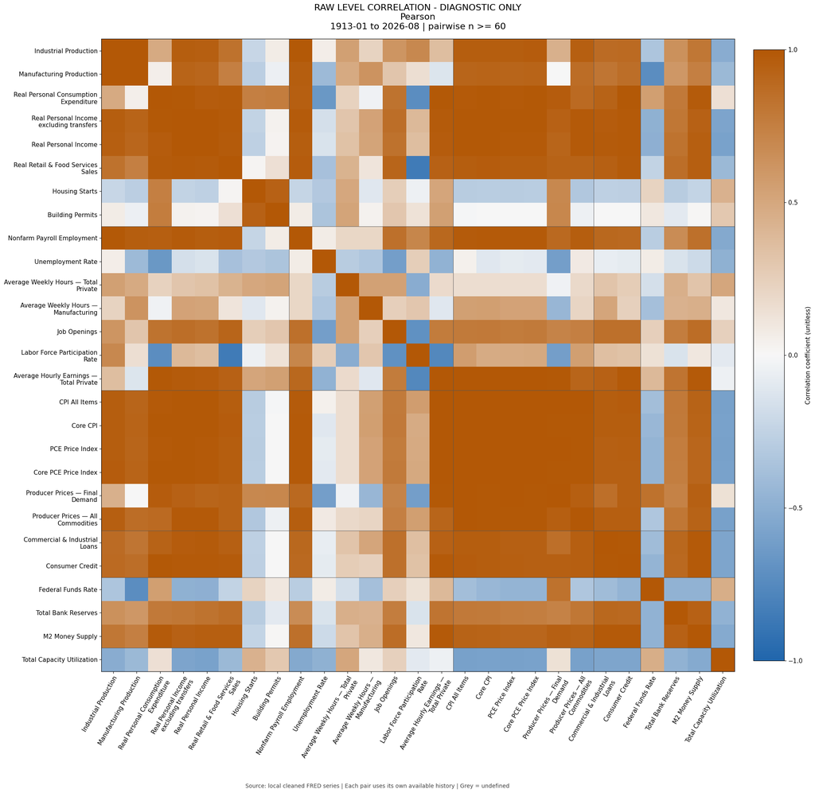

Raw levels expose broad shared trends. Use the change panels below for the requested exploratory comparison; high raw-level correlation alone is not economic evidence.

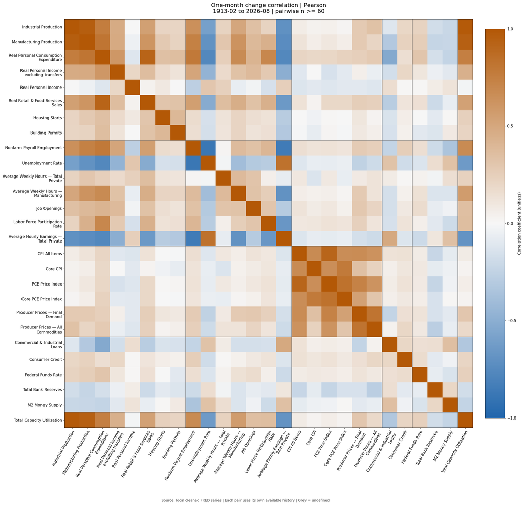

Pearson is sensitive to large observations. The next panel compares ranks using the same transformation and pairwise availability rules.

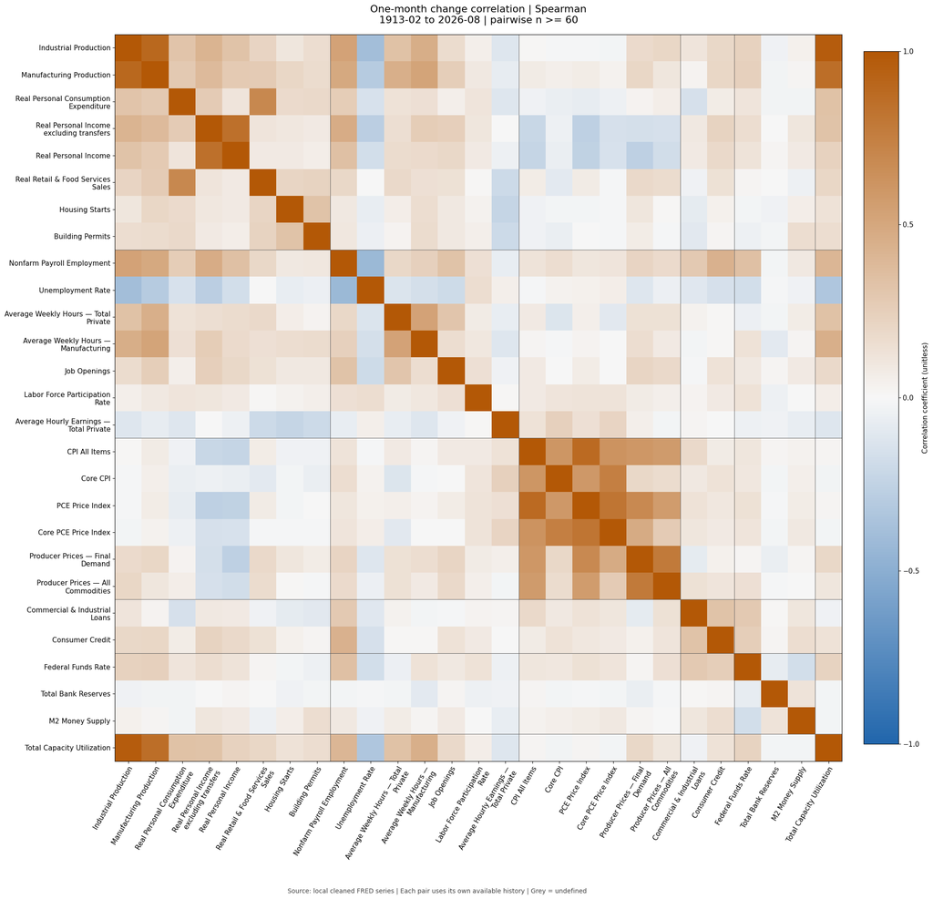

### 10. Unique transformed Pearson pairs and category context

```
Top 20 strongest positive change correlations:
```

| Dataset 1 | Dataset 2 | Correlation | Overlapping observations | Category 1 | Category 2 |
| --- | --- | --- | --- | --- | --- |
| Industrial Production | Total Capacity Utilization | 0.9837 | 714 | Growth / Activity | External / Structural |
| Industrial Production | Manufacturing Production | 0.9561 | 654 | Growth / Activity | Growth / Activity |
| Manufacturing Production | Total Capacity Utilization | 0.9385 | 654 | Growth / Activity | External / Structural |
| Real Personal Consumption Expenditure | Real Retail & Food Services Sales | 0.9213 | 232 | Growth / Activity | Growth / Activity |
| CPI All Items | PCE Price Index | 0.9113 | 808 | Inflation | Inflation |
| PCE Price Index | Core PCE Price Index | 0.8306 | 810 | Inflation | Inflation |
| Unemployment Rate | Average Hourly Earnings — Total Private | 0.8290 | 243 | Labor | Labor |
| Producer Prices — Final Demand | Producer Prices — All Commodities | 0.8148 | 201 | Inflation | Inflation |
| Manufacturing Production | Real Personal Consumption Expenditure | 0.8080 | 234 | Growth / Activity | Growth / Activity |
| Real Personal Consumption Expenditure | Nonfarm Payroll Employment | 0.7847 | 234 | Growth / Activity | Labor |
| Core CPI | Core PCE Price Index | 0.7767 | 808 | Inflation | Inflation |
| Industrial Production | Real Personal Consumption Expenditure | 0.7594 | 234 | Growth / Activity | Growth / Activity |
| Real Personal Consumption Expenditure | Total Capacity Utilization | 0.7488 | 234 | Growth / Activity | External / Structural |
| Manufacturing Production | Nonfarm Payroll Employment | 0.7400 | 654 | Growth / Activity | Labor |
| PCE Price Index | Producer Prices — Final Demand | 0.7331 | 200 | Inflation | Inflation |
| Real Personal Consumption Expenditure | Labor Force Participation Rate | 0.6963 | 232 | Growth / Activity | Labor |
| Real Personal Consumption Expenditure | Average Weekly Hours — Manufacturing | 0.6796 | 234 | Growth / Activity | Labor |
| CPI All Items | Core CPI | 0.6789 | 833 | Inflation | Inflation |
| Nonfarm Payroll Employment | Total Capacity Utilization | 0.6771 | 714 | Labor | External / Structural |
| CPI All Items | Producer Prices — Final Demand | 0.6666 | 199 | Inflation | Inflation |

```
Top 20 strongest negative change correlations:
```

| Dataset 1 | Dataset 2 | Correlation | Overlapping observations | Category 1 | Category 2 |
| --- | --- | --- | --- | --- | --- |
| Nonfarm Payroll Employment | Unemployment Rate | -0.8786 | 941 | Labor | Labor |
| Nonfarm Payroll Employment | Average Hourly Earnings — Total Private | -0.8469 | 245 | Labor | Labor |
| Real Personal Consumption Expenditure | Average Hourly Earnings — Total Private | -0.7636 | 234 | Growth / Activity | Labor |
| Real Personal Consumption Expenditure | Unemployment Rate | -0.7636 | 232 | Growth / Activity | Labor |
| Manufacturing Production | Average Hourly Earnings — Total Private | -0.7275 | 244 | Growth / Activity | Labor |
| Industrial Production | Average Hourly Earnings — Total Private | -0.6998 | 244 | Growth / Activity | Labor |
| Manufacturing Production | Unemployment Rate | -0.6896 | 652 | Growth / Activity | Labor |
| Average Weekly Hours — Manufacturing | Average Hourly Earnings — Total Private | -0.6891 | 245 | Labor | Labor |
| Average Hourly Earnings — Total Private | Total Capacity Utilization | -0.6826 | 244 | Labor | External / Structural |
| Labor Force Participation Rate | Average Hourly Earnings — Total Private | -0.6638 | 243 | Labor | Labor |
| Real Retail & Food Services Sales | Average Hourly Earnings — Total Private | -0.6416 | 243 | Growth / Activity | Labor |
| Unemployment Rate | Total Capacity Utilization | -0.6386 | 712 | Labor | External / Structural |
| Industrial Production | Unemployment Rate | -0.5943 | 940 | Growth / Activity | Labor |
| Real Personal Consumption Expenditure | Commercial & Industrial Loans | -0.5341 | 234 | Growth / Activity | Credit |
| Real Retail & Food Services Sales | Unemployment Rate | -0.5176 | 413 | Growth / Activity | Labor |
| Real Personal Income excluding transfers | Average Hourly Earnings — Total Private | -0.4988 | 244 | Growth / Activity | Labor |
| Real Personal Income excluding transfers | Unemployment Rate | -0.4649 | 808 | Growth / Activity | Labor |
| Unemployment Rate | Average Weekly Hours — Manufacturing | -0.3925 | 941 | Labor | Labor |
| Nonfarm Payroll Employment | M2 Money Supply | -0.3441 | 810 | Labor | Policy / Liquidity |
| Commercial & Industrial Loans | Total Capacity Utilization | -0.3266 | 714 | Credit | External / Structural |

```
Pairs with fewer than 60 shared changes: 0
```

### 11. Calculation and input-integrity checks

```
Checks passed: 351 unique change pairs; consecutive-month rules; input CSVs unchanged.
```

## Takeaways

### 12. Computed summary and provenance

- **Monthly variables:** 27; transformed: 27.

- **Raw coverage:** 1913-01-01 to 2026-08-01; change coverage: 1913-02-01 to 2026-08-01.

- **Unique pairs:** 351; defined Pearson: 351; defined Spearman: 351.

- **Highest positive transformed Pearson:** Industrial Production / Total Capacity Utilization: r=0.9837, n=714, 1967-02 to 2026-07.

- **Most negative transformed Pearson:** Nonfarm Payroll Employment / Unemployment Rate: r=-0.8786, n=941, 1948-02 to 2026-08.

- **Change overlap:** 199 to 1290 observations; below 60: 0 pairs.

- **Frequency exclusions:** Initial Claims, SLOOS: Banks Tightening C&I Lending Standards, SLOOS: Stronger Demand for C&I Loans, Delinquency Rate on Business Loans, Reserve Balances with Federal Reserve Banks, Federal Reserve Total Assets, Real Exports of Goods and Services, Real Imports of Goods and Services, Nonfarm Business Sector Labor Productivity.

- **Missing transformation exclusions:** None.

**Interpretation:** these are contemporaneous, pairwise associations with different historical windows. The rankings do not establish causality, leading relationships, or predictive power. Raw-level trends and extreme observations can influence correlations; Pearson/Spearman comparisons are diagnostic. No benchmark, z-score, PCA, clustering, regime, or trained model is produced.

```
All analysis exports: C:\Users\HYPE AMD\Desktop\CHronoZ-Economic-Modelling\outputs\correlation
```